# PD5

Ngoc Anh Nguyen, Piotr Piątyszek

12/6/2019

## Ankieta

LINK DO ANKIETY

Ankieta o środkach transportu i wynikach wyborów w Niemczech miała na celu sprawdzenie jak różne rodzaje wykresów wpływają na czytelność danych w nich zawartych oraz jakie problemy z czytaniem danych występują w przypadku określonych rodzajów wykresów.

Sprawdziliśmy jaki błąd popełniają osoby odczytujące wykresy treemap oraz bubble chart w odniesieniu do wykresu słupkowego. Wpierw pokazaliśmy im testowyany wykres i zadaliśmy 3 pytania, a następnie pokazaliśmy wykres wzorcowy - słupkowy i ponownie zadaliśmy te same pytania.

### Dane o środkach transportu

Wykres bąbelkowy

Wykres słupkowy

[figure not shown]

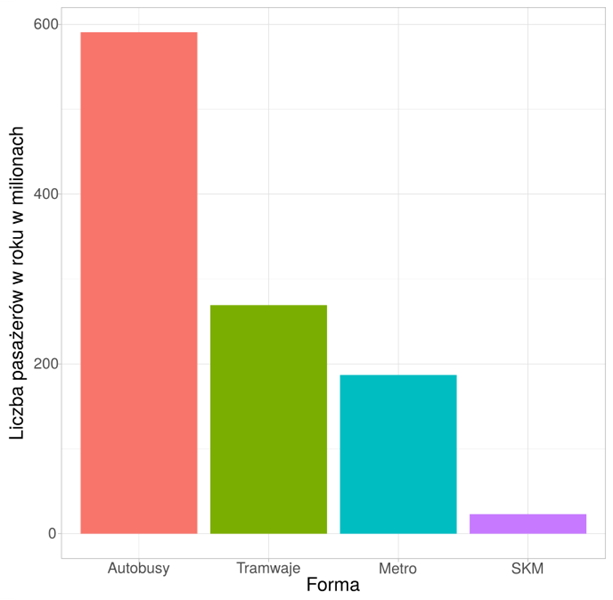

#### Pytania

1. Ile razy więzej przewozów wykonały autobusy niż metro?
2. Ile przewozów wykonały tramwaje + metro? (z dokładnością do 10% całości)
- Mniej niż autobusy
- Więcej niż autobusy
- Tyle samo co autobusy
3. Jaki udział w % we wszystkich przewozach ma SKM?

### Dane o wyborach w niemczech

Treemap

Wykres słupkowy

[figure not shown]

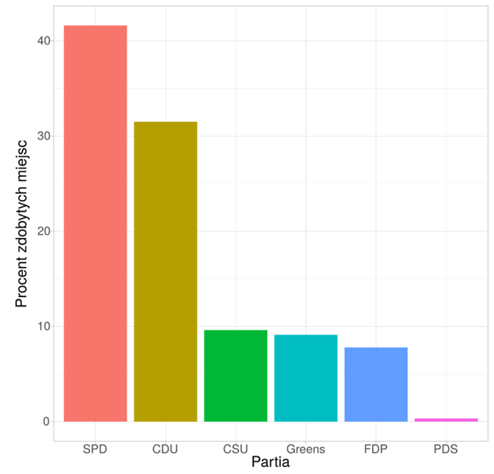

#### Pytania

1. Oszacuj jaki % miejsc przypadł partii zielonych (Greens)
2. Która partia dostała więcej miejsc, CSU czy Zieloni
3. Reprezentujesz partię SPD. Koalicja z jaką najmniejszą partią zapewni ci więcej niż połowę miejsc.

## Bubble Chart

### Porównanie błędów

Porównanie wartości - Pytanie 1

Dodawanie wartości - Pytanie 2

Szacowanie wartości - Pytanie 3

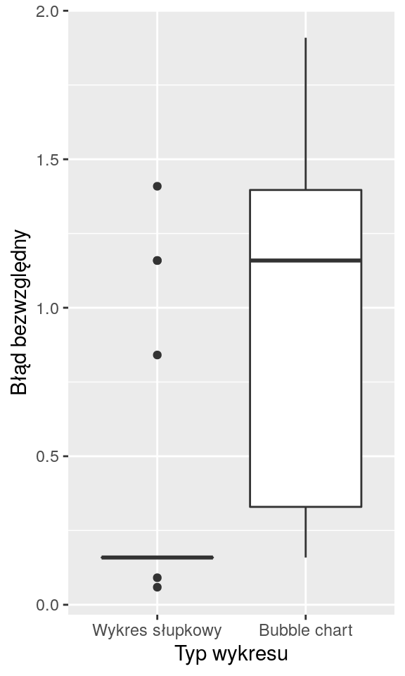

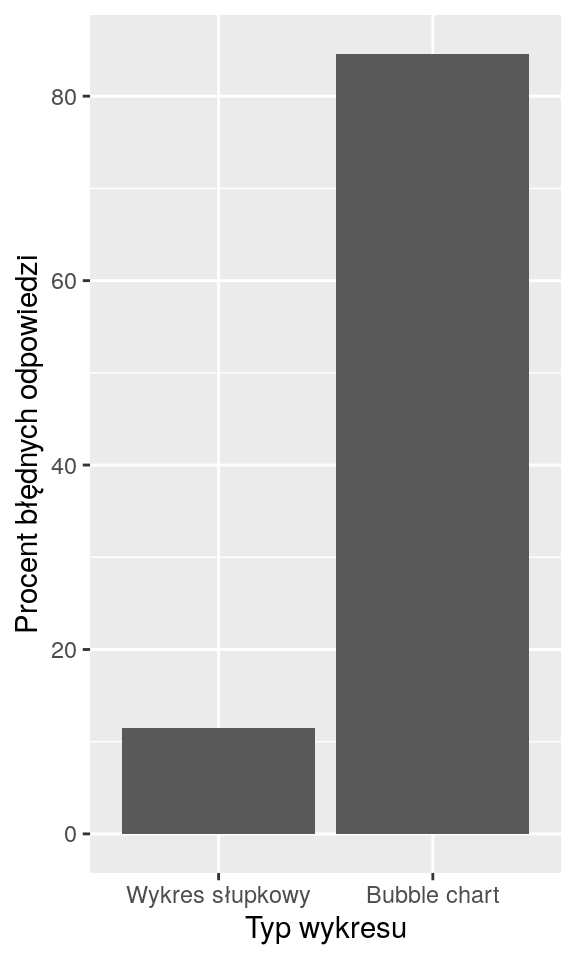

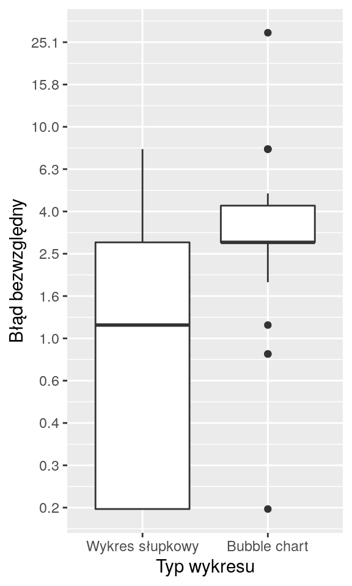

## Treemap

### Porównanie błędów

Szacowanie wartości - Pytanie 1

Porównywanie wartości - Pytanie 2

Precyzyjne dodawanie wartości - Pytanie 3

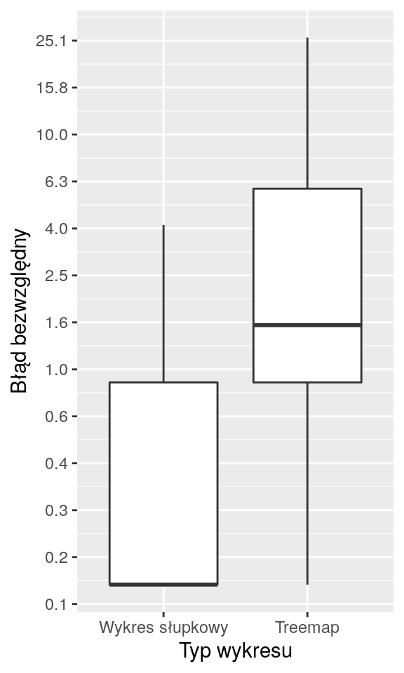

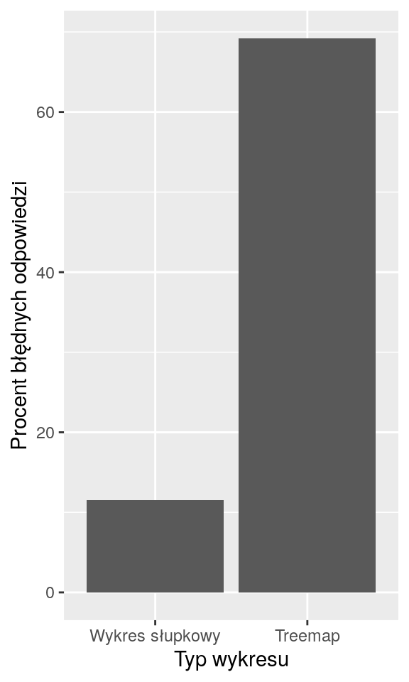

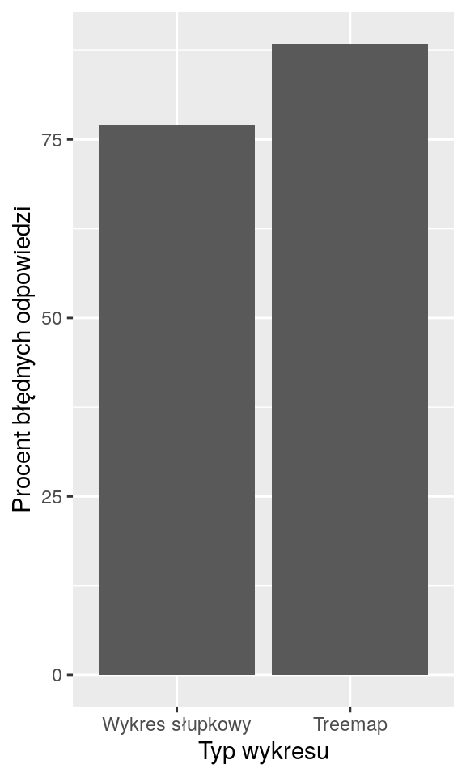

## Stosunek błędów

Podzieliśmy błąd przy odczytywaniu z wykresu bąbelkowego przez błąd przy odczytywaniu z wykresu słupkowego

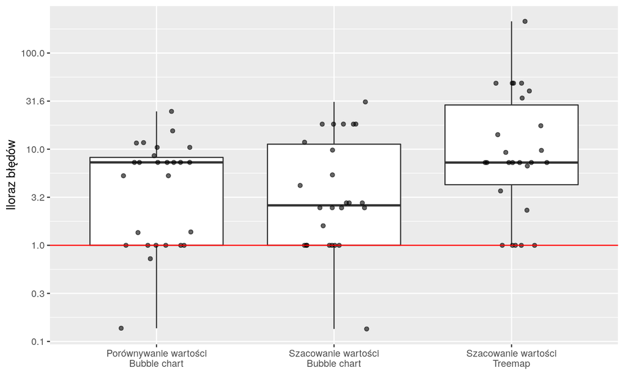

## Wnioski

W przypadku gdy trzeba porównywać wielkości niemal zawsze odpowiedzi z wykresu bąbelkowego były błędne. Treemap też nie wypadła za dobrze - około 70% pytanych odpowiedziało niepoprawnie na pytanie 2.

Jeśli chodzi o szacowanie wartości to najbardziej zwodniczym okazał się wykres typu Treemap, natomiast w wykresie bąbelkowym błąd bezwzględny był skupiony wokół 3 - dużo osób odpowiadało 5, gdy poprawna odpowiedź to 2.15 może świadczyć to o pewnej skłonności wszystkich czytających wykres - wszyscy nabrali się w ten sam sposób.